# R Basics

# Software

R is a programming language that is especially powerful for data exploration, visualization, and statistical analysis. To interact with R, we will use RStudio.

The following software is required for this workshop:

### R [Free]: The R Project for Statistical Computing.

- Download R for your platform here: https://cloud.r-project.org/
- Install

### RStudio [Free]: A powerful and productive user interface for R. It’s free and open source, and works great on Windows, Mac, and Linux.

- https://www.rstudio.com/products/rstudio/download/
- Download and install
- Attention: Download and install R FIRST! from the link above.

#### Attention Mac users!

Some functions in R require an “X11 Server” and/or libraries associated with an X11 server. Apple does not provide this software with OS X anymore so you have to do it on your own via a third-party application called XQuartz.

1. Please close all the programs.
2. Go to http://xquartz.macosforge.org/landing/ and download the top-most “quick download” disk image file.
3. Double click the downloaded disk image then double click on the XQuartz.pkg and follow the installation steps.
4. Please restart your machine.

# R Basics

R is a powerful language and environment for statistical computing. R is a freeware and can be installed on any computers for free. R is frequently used to analyze and visualize data in many scientific applications. R in combination with RStudio is a great option for educators as it allows easy data simulations, data analysis, and data visualization all within one powerful interface. This short tutorial will be covering basics of R use within RStudio interface.

## RStudio layout

**Bottom left:** console window for typing simple commands.

**Top left:** editor window. Collection of commands (scripts) can be edited here using a simple word editor.

**Top right:** workspace/history window. Here you can view data and values loaded into R memory.

**Bottom right:** Files/plots/packages/help window. Here you can navigate and open your files, see your plots, load necessary package, and search for help.

## Creating and executing scripts

- Open RStudio
- Create new R script file: File ! New File ! R Script
- Save this script file in our Project folder (name it RScript)

In the editor window (newly created R script file) let’s type:

```r
print("Hello world!")
```

Make sure that cursor is on the line with print(“Hello world”) and hit Ctrl+Enter

```
## [1] "Hello world!"
```

in the console window.

To execute a piece of code you can highlight that code and hit *Run* on the top right of your editor window. You can also place a cursor on the line of code you want to execute and hit *Ctrl+Enter* or hit Run at the top of your editor window.

## Using R as a calculator

In the command window after the “>” type:

```r
2+2
```

when you hit Enter you should see this output

```
## [1] 4
```

## Assignment operator

“<-” used to assign a value to a variable

### Example 1:

```r
cat<-2
dog<-3
cat*dog
```

when you hit Enter you should see this output

```
## [1] 6
```

What we did is:

- we assigned 2 to variable “cat”
- we assigned 3 to variable “dog”
- we then multiplied those two variables

### Example 2:

```r
x <- c(1,2,3,4,5,6)
y<-x^2
print(y)
```

```
## [1]  1  4  9 16 25 36
```

In the code above, “c” is a function that combines its arguments into a vector (a string of numbers).

```r
y <- x^2
```

Squares the elements of x and assign product to y

```r
print(y)
```

Print is a function that prints its argument on the screen.

```r
# Runing the code will produce this output.
# Note that "#" is used here to comment lines.
# Anything after "#" will not be passed for code evaluation by R

x <- c(1,2,3,4,5,6)
y<-x^2
print(y)
```

```
## [1]  1  4  9 16 25 36
```

## Functions

### The anatomy of a Function. Typos averse

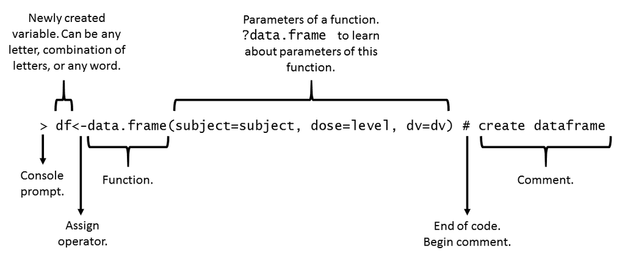

### Example 1: mean

To compute a mean you could type

```r
b<-(10+20+30)/3
b
```

```
## [1] 20
```

but if vector is long this will take long time

the alternative is to use an existing function like mean()

For example:

```r
mean(x=b) # b is a vector we defined earlier
```

```
## [1] 20
```

To compute a mean you could type

```r
b<-(10+20+30)/3
b
```

```
## [1] 20
```

but if vector is long this will take long time

the alternative is to use an existing function like mean()

For example:

```r
mean(x=b) # b is a vector we defined earlier
```

```
## [1] 20
```

### Example 2: rnorm

- rnorm() is an example of another existing function
- this function creates random numbers
- rnorm(10) will create 10 random numbers

### Example 3: rnorm with constraints

If we need 10 random numbers with certain parameters:

- rnorm(10, mean=1.2, sd=3.4)
- This will output a normal distribution with mean 1.2 and standard deviation 3.4.

### Example 3: rnorm with constraints

If we need 10 random numbers with certain parameters:

- rnorm(10, mean=1.2, sd=3.4)
- This will output a normal distribution with mean 1.2 and standard deviation 3.4.

```r
rnorm(10, mean=1.2, sd=3.4)
```

```
##  [1]  2.7704937  2.5132808 -2.2675443  1.6289180 -1.8793405  9.3171258
##  [7]  1.9767155 -0.1236568  6.2288761  6.5376189
```

### Example 4: histogram

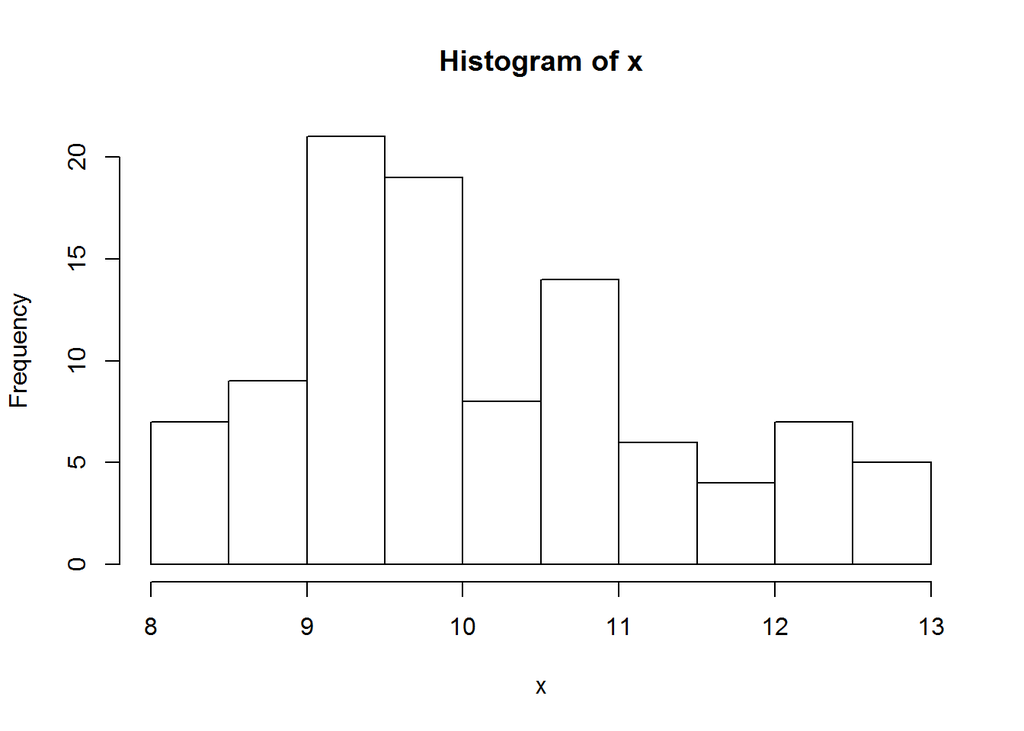

```r
x=rnorm(100, mean=10, sd=1.2)
hist(x) # will output a histogram of x below
```